# Evan Richardson Final Project

## Final Project

By Evan Richardson

[Github Repo](https://github.com/ejrich/chess-predictions)

I've enjoyed chess for a long time and have wanted to dive into machine learning in the deep end right away. For this project, I would like to analyze the position of the pieces for the most likely outcome given equal skilled players. In order to gather the data for this project, I will initially load PGN(portable game notation for games) data gathered from https://www.ficsgames.org/download.html for games above 2000 rating. From this data, I created a a data loader to interpret each move and create a snapshot of the game after each move, and hopefully from this project I can create a model that will predict who will likely win from the given state of the game.

```python
import numpy as np
import pandas as pd
import matplotlib.pyplot as plt
import seaborn as sns

from sklearn.ensemble import RandomForestRegressor
from sklearn.linear_model import SGDRegressor
from sklearn.linear_model import SGDClassifier
from sklearn.metrics import accuracy_score
from sklearn.metrics import confusion_matrix
from sklearn.metrics import log_loss
from sklearn.metrics import mean_squared_error
from sklearn.model_selection import train_test_split
from sklearn.preprocessing import Imputer
from sklearn.preprocessing import LabelEncoder
from sklearn.preprocessing import StandardScaler

%matplotlib inline
```

### Hypothesis

From this project, I hope to find which positions are the best to be in for chess and the probability of wins given these positions. This can be applied to any chess systems, and in general feeds into my curiousity about the game. I'm not aiming to create a predictive move model, just to find who is in the advantage in certain situations.

### Dataset

All the data I have gathered is from https://www.ficsgames.org/download.html, which provides data for a lot of games, over 7000 in January 2018 alone. The data provided however is not a csv, but PGN, so I wrote an interpreter to translate the moves in the file to actual board states after every move, and from these game states, I wrote the result for testing the data, the number of each piece for each player and their total number of pieces, along with the piece and the color of the piece for each square on the board, flattening the board object.

An example game notated with PGN looks like this:

1. e4 c5 2. f4 e6 3. Nf3 Nc6 4. d3 d5 5. e5 Qa5+ 6. c3 Nh6 7. Be2 Be7 8. O-O O-O 9. Re1 Qb6 10. Nbd2 c4+ 11. d4 Nf5 12. Nf1 Bd7 13. g4 Nh4 14. Kh1 Nxf3 15. Bxf3 Bh4 16. Re2 Rad8 17. Rg2 a6 18. Ng3 Ne7 19. Nh5 Qa5 20. Bd2 Qb5 21. Be1 Bxe1 22. Qxe1 h6 23. g5 hxg5 24. Rxg5 Ng6 25. Qg3 Qxb2 26. Rg1 Qxc3 27. Nf6+ gxf6 28. Rxg6+ fxg6 29. Qxg6+ Kh8 30. Qh6# {Black checkmated} 1-0

```python
df = pd.read_csv('../data/201801_games_2.csv')
```

```python
df.head()
```

|  | Result | WhitePawns | BlackPawns | WhiteRooks | BlackRooks | WhiteBishops | BlackBishops | WhiteKnights | BlackKnights | WhiteQueen | ... | d8_color | d8_piece | e8_color | e8_piece | f8_color | f8_piece | g8_color | g8_piece | h8_color | h8_piece |
| --- | --- | --- | --- | --- | --- | --- | --- | --- | --- | --- | --- | --- | --- | --- | --- | --- | --- | --- | --- | --- | --- |
| 0 | 1.0 | 8 | 8 | 2 | 2 | 2 | 2 | 2 | 2 | 1 | ... | 2.0 | Q | 2.0 | K | 2.0 | B | 2.0 | N | 2.0 | R |
| 1 | 1.0 | 8 | 8 | 2 | 2 | 2 | 2 | 2 | 2 | 1 | ... | 2.0 | Q | 2.0 | K | 2.0 | B | 2.0 | N | 2.0 | R |
| 2 | 1.0 | 8 | 8 | 2 | 2 | 2 | 2 | 2 | 2 | 1 | ... | 2.0 | Q | 2.0 | K | 2.0 | B | 2.0 | N | 2.0 | R |
| 3 | 1.0 | 8 | 8 | 2 | 2 | 2 | 2 | 2 | 2 | 1 | ... | 2.0 | Q | 2.0 | K | 2.0 | B | 2.0 | N | 2.0 | R |
| 4 | 1.0 | 8 | 8 | 2 | 2 | 2 | 2 | 2 | 2 | 1 | ... | 2.0 | Q | 2.0 | K | 2.0 | B | 2.0 | N | 2.0 | R |

5 rows × 143 columns

```python
df.shape
```

```
(498020, 143)
```

The color and piece columns are coded, with color having values of '' = Empty, 1 = White, and 2 = Black.

Pieces are '' = Empty, P = Pawn, R = Rook, B = Bishop, N = Knight, Q = Queen, and K = King.

The piece counts are continuous based on the number of pieces on the board for each side.

Result also has the possibility to be 1 = White win, 0.5 = Draw, and 0 = Black win. This leads to interesting possibilities for approaches as well, since I could likely use classification or regression depending on the approach.

Classification can predict the winner, but regression has the advantage of being able to predict who is likely winning the game in the current board state.

### Data Preprocessing

Since I created this dataset, all of the columns have value and don't need to be removed. There are empty values for the squares where there isn't a piece, but these should still be empty, and when I convert them to one-hot encodings, the dummy columns will all be 0's.

For each square, the color and piece are categorical, so I will create dummy variables to encode the column.

```python
numerical_columns = list(df.columns[1:-128])
print(numerical_columns)

categorical_columns = list(df.columns[-128:])
print(categorical_columns)
```

```
['WhitePawns', 'BlackPawns', 'WhiteRooks', 'BlackRooks', 'WhiteBishops', 'BlackBishops', 'WhiteKnights', 'BlackKnights', 'WhiteQueen', 'BlackQueen', 'WhiteKing', 'BlackKing', 'WhiteTotal', 'BlackTotal']
['a1_color', 'a1_piece', 'b1_color', 'b1_piece', 'c1_color', 'c1_piece', 'd1_color', 'd1_piece', 'e1_color', 'e1_piece', 'f1_color', 'f1_piece', 'g1_color', 'g1_piece', 'h1_color', 'h1_piece', 'a2_color', 'a2_piece', 'b2_color', 'b2_piece', 'c2_color', 'c2_piece', 'd2_color', 'd2_piece', 'e2_color',…
```

I want to make sure all pieces and colors are represented in the dummy columns

```python
pieces = ['P', 'B', 'R', 'N', 'Q', 'K']
colors = ['1.0', '2.0']
```

```python
def mapColumns(col_name, columns):
    return list(map(lambda x: col_name + '_' + x, columns))
```

```python
dummy_columns = {}
for col_name in categorical_columns:
    dummies = pd.get_dummies(df[col_name], prefix=col_name)
    reindex_columns = mapColumns(col_name, pieces) if 'piece' in col_name else mapColumns(col_name, colors)
    dummies = dummies.reindex(columns=reindex_columns, fill_value=0)

    dummy_columns[col_name] = dummies.columns.values
    df = df.merge(dummies, left_index=True, right_index=True)
    df = df.drop(columns=col_name)
```

```python
for col_name, dummies in dummy_columns.items():
    print(col_name, dummies)
```

```
a1_color ['a1_color_1.0' 'a1_color_2.0']
a1_piece ['a1_piece_P' 'a1_piece_B' 'a1_piece_R' 'a1_piece_N' 'a1_piece_Q'
 'a1_piece_K']
b1_color ['b1_color_1.0' 'b1_color_2.0']
b1_piece ['b1_piece_P' 'b1_piece_B' 'b1_piece_R' 'b1_piece_N' 'b1_piece_Q'
 'b1_piece_K']
c1_color ['c1_color_1.0' 'c1_color_2.0']
c1_piece ['c1_piece_P' 'c1_piece_B' 'c1_piece_R' 'c1_piece_N' 'c1_piece_Q'
 'c1_piece_K']
d1_color ['d1_color_1.0' 'd1_color_2.0']
d1_piece ['d1_piece_P' 'd1_piece_B' 'd1_piece_R' 'd1_piece_N' 'd1_piece_Q'
 'd1_piece_K']
e1_color ['e1_color_1.0' 'e1_color_2.0']
e1_piece ['e1_piece_P' 'e1_piece_B' 'e1_piece_R' 'e1_piece_N' 'e1_piece_Q'
 'e1_piece_K']
f1_color ['f1_color_1.0' 'f1_color_2.0']
f1_piece ['f1_piece_P' 'f1_piece_B' 'f1_piece_R' 'f1_piece_N' 'f1_piece_Q'
 'f1_piece_K']
g1_color ['g1_color_1.0' 'g1_color_2.0']
g1_piece ['g1_piece_P' 'g1_piece_B' 'g1_piece_R' 'g1_piece_N' 'g1_piece_Q'
 'g1_piece_K']
h1_color ['h1_color_1.0' 'h1_color_2.0']
h1_piece ['h1_piece_P' 'h1_piece_B' 'h1_piece_R' 'h1_piece_N' 'h1_piece_Q'
 'h1_piece_K']
a2_color ['a2_color_1.0' 'a2_color_2.0']
a2_piece ['a2_piece_P' 'a2_piece_B' 'a2_piece_R' 'a2_piece_N' 'a2_piece_Q'
 'a2_piece_K']
b2_color ['b2_color_1.0' 'b2_color_2.0']
b2_piece ['b2_piece_P' 'b2_piece_B' 'b2_piece_R' 'b2_piece_N' 'b2_piece_Q'
 'b2_piece_K']
c2_color ['c2_color_1.0' 'c2_color_2.0']
c2_piece ['c2_piece_P' 'c2_piece_B' 'c2_piece_R' 'c2_piece_N' 'c2_piece_Q'
 'c2_piece_K']
d2_color ['d2_color_1.0' 'd2_color_2.0']
d2_piece ['d2_piece_P' 'd2_piece_B' 'd2_piece_R' 'd2_piece_N' 'd2_piece_Q'
 'd2_piece_K']
e2_color ['e2_color_1.0' 'e2_color_2.0']
e2_piece ['e2_piece_P' 'e2_piece_B' 'e2_piece_R' 'e2_piece_N' 'e2_piece_Q'
 'e2_piece_K']
f2_color ['f2_color_1.0' 'f2_color_2.0']
```

[output cut: 137 more lines]

```
d8_color ['d8_color_1.0' 'd8_color_2.0']
d8_piece ['d8_piece_P' 'd8_piece_B' 'd8_piece_R' 'd8_piece_N' 'd8_piece_Q'
 'd8_piece_K']
e8_color ['e8_color_1.0' 'e8_color_2.0']
e8_piece ['e8_piece_P' 'e8_piece_B' 'e8_piece_R' 'e8_piece_N' 'e8_piece_Q'
 'e8_piece_K']
f8_color ['f8_color_1.0' 'f8_color_2.0']
f8_piece ['f8_piece_P' 'f8_piece_B' 'f8_piece_R' 'f8_piece_N' 'f8_piece_Q'
 'f8_piece_K']
g8_color ['g8_color_1.0' 'g8_color_2.0']
g8_piece ['g8_piece_P' 'g8_piece_B' 'g8_piece_R' 'g8_piece_N' 'g8_piece_Q'
 'g8_piece_K']
h8_color ['h8_color_1.0' 'h8_color_2.0']
h8_piece ['h8_piece_P' 'h8_piece_B' 'h8_piece_R' 'h8_piece_N' 'h8_piece_Q'
 'h8_piece_K']
```

```python
df.head()
```

|  | Result | WhitePawns | BlackPawns | WhiteRooks | BlackRooks | WhiteBishops | BlackBishops | WhiteKnights | BlackKnights | WhiteQueen | ... | g8_piece_Q | g8_piece_K | h8_color_1.0 | h8_color_2.0 | h8_piece_P | h8_piece_B | h8_piece_R | h8_piece_N | h8_piece_Q | h8_piece_K |
| --- | --- | --- | --- | --- | --- | --- | --- | --- | --- | --- | --- | --- | --- | --- | --- | --- | --- | --- | --- | --- | --- |
| 0 | 1.0 | 8 | 8 | 2 | 2 | 2 | 2 | 2 | 2 | 1 | ... | 0 | 0 | 0 | 1 | 0 | 0 | 1 | 0 | 0 | 0 |
| 1 | 1.0 | 8 | 8 | 2 | 2 | 2 | 2 | 2 | 2 | 1 | ... | 0 | 0 | 0 | 1 | 0 | 0 | 1 | 0 | 0 | 0 |
| 2 | 1.0 | 8 | 8 | 2 | 2 | 2 | 2 | 2 | 2 | 1 | ... | 0 | 0 | 0 | 1 | 0 | 0 | 1 | 0 | 0 | 0 |
| 3 | 1.0 | 8 | 8 | 2 | 2 | 2 | 2 | 2 | 2 | 1 | ... | 0 | 0 | 0 | 1 | 0 | 0 | 1 | 0 | 0 | 0 |
| 4 | 1.0 | 8 | 8 | 2 | 2 | 2 | 2 | 2 | 2 | 1 | ... | 0 | 0 | 0 | 1 | 0 | 0 | 1 | 0 | 0 | 0 |

5 rows × 527 columns

### Data Analysis and Visualization

Chess can be a very subjective game as to who holds the better position, so from this dataset, I think the only thing I really should be considering is that the distribution of white wins is close to black wins, and that there is a significant amount of draws since this data will also help train the model to produce results between a white or black win.

```
1.0    205340
0.0    189996
0.5    102684
Name: Result, dtype: int64
```

```
Text(0,0.5,'Number of Results')
```

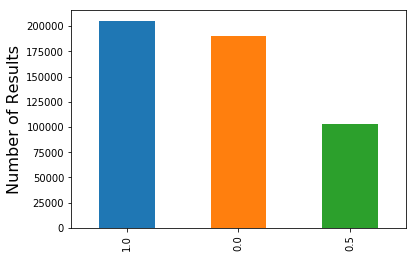

```python
result_counts = df["Result"].value_counts()
print(result_counts)
result_counts.plot.bar()
plt.ylabel("Number of Results", fontsize=16)
```

From this initial exploration, we can see that white wins are the most prevalent among the dataset, but pretty close to black wins with draws being about half of white wins, so this dataset will work well for my predictions.

### Data Modeling and Prediction

#### Linear Regression

As a first pass, I'm going to try to model with linear regression, hopefully ending up with a model that returns a number between 0 and 1 to represent the probability that white or black will win the game.

```python
df_train, df_test = train_test_split(df)
print(df.shape[0], df_train.shape[0], df_test.shape[0])
```

```
498020 373515 124505
```

```python
y_train = df_train["Result"].values
y_test = df_test["Result"].values
```

```python
zeros_train = np.zeros(df_train.shape)
zeros_test = np.zeros(df_test.shape)
null_lr = SGDRegressor(max_iter=2000)
null_lr.fit(zeros_train, y_train)
pred_result_null_test = null_lr.predict(zeros_test)
null_mse = mean_squared_error(y_test, pred_result_null_test)
null_rmse = np.sqrt(null_mse)

print("Null Model MSE:", null_mse)
print("Null Model RMSE:", null_rmse)
```

```
Null Model MSE: 0.19827831389397432
Null Model RMSE: 0.44528453138861035
```

```python
def create_feature_matrices(df_train, df_test, selected_columns, dummy_columns):
    """
    Creates feature matrices for the training and testing sets from the given dataframes.
    The feature matrices are built from the columns given in selected columns.
    """

    # keep track of numerical features
    numerical_trial_columns = []

    # keep track of dummy features for categorical variables
    categorical_trial_columns = []

    # build feature lists
    for col_name in selected_columns:
        if col_name in dummy_columns:
            categorical_trial_columns.extend(dummy_columns[col_name])
        else:
            numerical_trial_columns.append(col_name)

    # transform numerical features
    if len(numerical_trial_columns) > 0:
        X_train_numerical = df_train[numerical_trial_columns].astype("float64").values
        X_test_numerical = df_test[numerical_trial_columns].astype("float64").values

        scaler = StandardScaler()
        X_train_numerical = scaler.fit_transform(X_train_numerical)
        X_test_numerical = scaler.transform(X_test_numerical)

    # select categorical features
    if len(categorical_trial_columns) > 0:
        X_train_categorical = df_train[categorical_trial_columns].astype("float64").values
        X_test_categorical = df_test[categorical_trial_columns].astype("float64").values

    # concatenate feature matrices
    if len(numerical_trial_columns) > 0 and len(categorical_trial_columns) > 0:
        X_train = np.hstack([X_train_numerical, X_train_categorical])
        X_test = np.hstack([X_test_numerical, X_test_categorical])
    elif len(numerical_trial_columns) > 0:
        X_train = X_train_numerical
        X_test = X_test_numerical
    else:
        X_train = X_train_categorical
        X_test = X_test_categorical

    return X_train, X_test
```

```python
all_columns = numerical_columns + categorical_columns

X_train, X_test = create_feature_matrices(df_train, df_test, all_columns, dummy_columns)

all_lr = SGDRegressor(max_iter=2000)
all_lr.fit(X_train, y_train)
pred_result_all_test = all_lr.predict(X_test)
all_mse = mean_squared_error(y_test, pred_result_all_test)
all_rmse = np.sqrt(all_mse)

print("Base Model MSE:", null_mse)
print("Base Model RMSE:", null_rmse)
print()
print("All Columns Model MSE:", all_mse)
print("All Columns Model RMSE:", all_rmse)
```

```
Base Model MSE: 0.19827831389397432
Base Model RMSE: 0.44528453138861035

All Columns Model MSE: 0.1635828547849856
All Columns Model RMSE: 0.40445377335980637
```

```
(-0.7859918701227345, 1.9830955403743302)
```

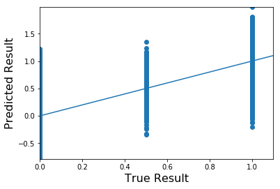

```python
plt.scatter(y_test, pred_result_all_test)
m = max(max(y_test), max(pred_result_all_test))
plt.plot([0, m], [0, m])
plt.xlabel("True Result", fontsize=16)
plt.ylabel("Predicted Result", fontsize=16)
plt.xlim([0, 1.1])
plt.ylim([min(pred_result_all_test), max(pred_result_all_test)])
```

These results don't look the greatest, so I'm going to try logistic regression to determine if this method will produce better results.

#### Logistic Regression

```python
df_train, df_test = train_test_split(df, stratify=df["Result"])
print(df.shape[0], df_train.shape[0], df_test.shape[0])
```

```
498020 373515 124505
```

```python
encoder = LabelEncoder()
y_train = encoder.fit_transform(df_train["Result"].astype("str"))
y_test = encoder.transform(df_test["Result"].astype("str"))
print(y_train)
```

```
[1 1 2 ... 2 1 1]
```

```python
X_train, X_test = create_feature_matrices(df_train, df_test, all_columns, dummy_columns)

lr = SGDClassifier(max_iter=2000, loss="log")
lr.fit(X_train, y_train)
pred_results = lr.predict(X_test)
pred_prob = lr.predict_proba(X_test)

accuracy = accuracy_score(y_test, pred_results)
loss = log_loss(y_test, pred_prob)
cm = confusion_matrix(y_test, pred_results)

print()
print("Model Accuracy:", accuracy)
print("Loss:", loss)
print("Labels:", encoder.classes_)
print("Confusion matrix:")
print(cm)
```

```
Model Accuracy: 0.5697763142042488
Loss: 0.913862878099875
Labels: ['0.0' '0.5' '1.0']
Confusion matrix:
[[29453  2333 15713]
 [ 8787  5806 11078]
 [12968  2686 35681]]
```

One of the problems with this model is that it only predicts the outcome and doesn't give any confidence or indication of who is currently winning the game, only the predicted outcome. While this model still produces valuable results, I would like to know the player that is winning and by how much they are winning by. So it's not completely desired.

#### Random Forest Regression

Although random forest regression is somewhat niche, I feel like there might be an opportunity to produce a valuable model since if an input set for example a player has many more pieces, an accurate prediction could likely be made.

```python
df_train, df_test = train_test_split(df)
print(df.shape[0], df_train.shape[0], df_test.shape[0])
```

```
498020 373515 124505
```

```python
y_train = df_train["Result"].values
y_test = df_test["Result"].values
```

```python
all_columns = numerical_columns + categorical_columns

X_train, X_test = create_feature_matrices(df_train, df_test, all_columns, dummy_columns)

all_rf = RandomForestRegressor()
all_rf.fit(X_train, y_train)
pred_result_all_test = all_rf.predict(X_test)
all_mse = mean_squared_error(y_test, pred_result_all_test)
all_rmse = np.sqrt(all_mse)

print("All Columns Model MSE:", all_mse)
print("All Columns Model RMSE:", all_rmse)
```

```
All Columns Model MSE: 0.0584021305744621
All Columns Model RMSE: 0.24166532762161413
```

```
(0.0, 1.0)
```

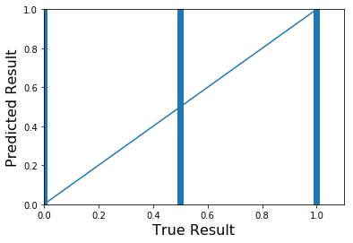

```python
plt.scatter(y_test, pred_result_all_test)
m = max(max(y_test), max(pred_result_all_test))
plt.plot([0, m], [0, m])
plt.xlabel("True Result", fontsize=16)
plt.ylabel("Predicted Result", fontsize=16)
plt.xlim([0, 1.1])
plt.ylim([min(pred_result_all_test), max(pred_result_all_test)])
```

From initial analysis of this result set, it appears that this model produces a clearer output, with a prediction of 0-1 being a possible better sign of who is currently winning. The potential problem in this model is that all ranges appear to be represented for each result.

### Results Analysis

In addition to creating these models, I also integrated each model into an api which I then called from a chess project I had been previously working on. After each move in the game, a call to each api is made and the predictions are displayed next to the board. So in addition to the data about the models, we can now demonstrate the model is working in practice.

This first example shows the first 5 moves of the first notation example I gave above.

[figure not shown]

From this current game state, black is obviously winning. They have more pieces developed in the middle of board and the queen on a5 has the white king in check, forcing white to play defensively.

All of the predictions here are valid, with different models producing different value. Logistic regression is the least descriptive, and linear and random forest both show about the same predictions.

[figure not shown]

This next game state is after turn 20. I chose this example to show because it demonstrates the flaws in the random forest model. Although the game state is relatively even with similar piece count and development, black is still slightly winning but it is much more even than the previous example. This example also begins to demonstrate the strength I discovered in the linear regression model, it actually made pretty accurate predictions.

[figure not shown]

This is the final game state, as black is checkmated here by the queen and rook in the g and h files. This example does show the relative weakness of the models. It seems like they tend to favor the respective number of pieces available for each player, as black in this case is up a rook and a pawn but white has the better position.

With this linear regression model, I believe the model is a fairly reliable predictor during the early to mid game, but when the late game comes and the position may be more important than the piece count, the model is not always reliable.